# COSC 2673/2793 | Machine Learning | Assignment 2

## Student Names: Thomas Williams, Hannah Mac

## Student numbers: s4005637, s4005524

# Reading Data

The following code uploads the image classification data to the notebook work environment and unzips it

```python
# Importing the image data.
import zipfile
with zipfile.ZipFile(r"Image_classification_data.zip", 'r') as zip_ref:
    zip_ref.extractall('./')
```

The dataset consists of the images ("patch_images") and a csv file ("data_labels_mainData"). The labels and the image paths are in the CSV file.

The csv file contains the following data:

- InstanceID (int)
- PatientID (int)
- ImageName (obj)
- cellTypeName (obj)
- cellType (int)
- isCancerous (int)

```python
# Visualising the csv file storing the links to the image data.
import numpy as np
from sklearn.model_selection import train_test_split
import pandas as pd

data = pd.read_csv('./data_labels_mainData.csv')
dataExtra = pd.read_csv('./data_labels_extraData.csv')

data.head()
```

|  | InstanceID | patientID | ImageName | cellTypeName | cellType | isCancerous |
| --- | --- | --- | --- | --- | --- | --- |
| 0 | 22405 | 1 | 22405.png | fibroblast | 0 | 0 |
| 1 | 22406 | 1 | 22406.png | fibroblast | 0 | 0 |
| 2 | 22407 | 1 | 22407.png | fibroblast | 0 | 0 |
| 3 | 22408 | 1 | 22408.png | fibroblast | 0 | 0 |
| 4 | 22409 | 1 | 22409.png | fibroblast | 0 | 0 |

# EDA

### In the code blocks below is the exploratory data analysis. The findings are discussed in a mark down at the end of the section.

```python
# Checking the distribution of values in all columns.
data.describe()
```

|  | InstanceID | patientID | cellType | isCancerous |
| --- | --- | --- | --- | --- |
| count | 9896.000000 | 9896.000000 | 9896.000000 | 9896.000000 |
| mean | 10193.880154 | 29.762025 | 1.501516 | 0.412187 |
| std | 6652.912660 | 17.486553 | 0.954867 | 0.492253 |
| min | 1.000000 | 1.000000 | 0.000000 | 0.000000 |
| 25% | 4135.750000 | 14.000000 | 1.000000 | 0.000000 |
| 50% | 9279.500000 | 26.000000 | 2.000000 | 0.000000 |
| 75% | 16821.250000 | 47.000000 | 2.000000 | 1.000000 |
| max | 22444.000000 | 60.000000 | 3.000000 | 1.000000 |

```python
# Checking for null/missing values and observing data types.
data.info()
```

```
<class 'pandas.core.frame.DataFrame'>
RangeIndex: 9896 entries, 0 to 9895
Data columns (total 6 columns):
 #   Column        Non-Null Count  Dtype
---  ------        --------------  -----
 0   InstanceID    9896 non-null   int64
 1   patientID     9896 non-null   int64
 2   ImageName     9896 non-null   object
 3   cellTypeName  9896 non-null   object
 4   cellType      9896 non-null   int64
 5   isCancerous   9896 non-null   int64
dtypes: int64(4), object(2)
memory usage: 464.0+ KB
```

```python
# Checking the distribution of cells for patient 4.
data1 = data[data["patientID"] == 4]
data1.head(20)
```

|  | InstanceID | patientID | ImageName | cellTypeName | cellType | isCancerous |
| --- | --- | --- | --- | --- | --- | --- |
| 188 | 18589 | 4 | 18589.png | fibroblast | 0 | 0 |
| 189 | 18590 | 4 | 18590.png | fibroblast | 0 | 0 |
| 190 | 18591 | 4 | 18591.png | fibroblast | 0 | 0 |
| 191 | 18592 | 4 | 18592.png | fibroblast | 0 | 0 |
| 192 | 18593 | 4 | 18593.png | fibroblast | 0 | 0 |
| 193 | 18594 | 4 | 18594.png | fibroblast | 0 | 0 |
| 194 | 18595 | 4 | 18595.png | fibroblast | 0 | 0 |
| 195 | 18596 | 4 | 18596.png | fibroblast | 0 | 0 |
| 196 | 18597 | 4 | 18597.png | fibroblast | 0 | 0 |
| 197 | 18598 | 4 | 18598.png | fibroblast | 0 | 0 |
| 198 | 18599 | 4 | 18599.png | fibroblast | 0 | 0 |
| 199 | 18600 | 4 | 18600.png | fibroblast | 0 | 0 |
| 200 | 18601 | 4 | 18601.png | fibroblast | 0 | 0 |
| 201 | 18602 | 4 | 18602.png | fibroblast | 0 | 0 |
| 202 | 18603 | 4 | 18603.png | fibroblast | 0 | 0 |
| 203 | 18604 | 4 | 18604.png | fibroblast | 0 | 0 |
| 204 | 18605 | 4 | 18605.png | fibroblast | 0 | 0 |
| 205 | 18606 | 4 | 18606.png | fibroblast | 0 | 0 |
| 206 | 18607 | 4 | 18607.png | fibroblast | 0 | 0 |
| 207 | 18608 | 4 | 18608.png | fibroblast | 0 | 0 |

```python
# Checking how that compares to the distribution of cells for patient 1.
data1 = data[data["patientID"] == 1]
data1.head(20)
```

|  | InstanceID | patientID | ImageName | cellTypeName | cellType | isCancerous |
| --- | --- | --- | --- | --- | --- | --- |
| 0 | 22405 | 1 | 22405.png | fibroblast | 0 | 0 |
| 1 | 22406 | 1 | 22406.png | fibroblast | 0 | 0 |
| 2 | 22407 | 1 | 22407.png | fibroblast | 0 | 0 |
| 3 | 22408 | 1 | 22408.png | fibroblast | 0 | 0 |
| 4 | 22409 | 1 | 22409.png | fibroblast | 0 | 0 |
| 5 | 22410 | 1 | 22410.png | fibroblast | 0 | 0 |
| 6 | 22411 | 1 | 22411.png | fibroblast | 0 | 0 |
| 7 | 22412 | 1 | 22412.png | fibroblast | 0 | 0 |
| 8 | 22413 | 1 | 22413.png | fibroblast | 0 | 0 |
| 9 | 22414 | 1 | 22414.png | fibroblast | 0 | 0 |
| 10 | 22415 | 1 | 22415.png | fibroblast | 0 | 0 |
| 11 | 22417 | 1 | 22417.png | inflammatory | 1 | 0 |
| 12 | 22418 | 1 | 22418.png | inflammatory | 1 | 0 |
| 13 | 22419 | 1 | 22419.png | inflammatory | 1 | 0 |
| 14 | 22420 | 1 | 22420.png | inflammatory | 1 | 0 |
| 15 | 22421 | 1 | 22421.png | inflammatory | 1 | 0 |
| 16 | 22422 | 1 | 22422.png | inflammatory | 1 | 0 |
| 17 | 22423 | 1 | 22423.png | others | 3 | 0 |
| 18 | 22424 | 1 | 22424.png | others | 3 | 0 |

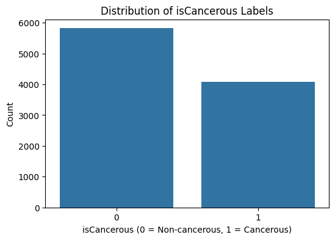

```
isCancerous
0    5817
1    4079
Name: count, dtype: int64
```

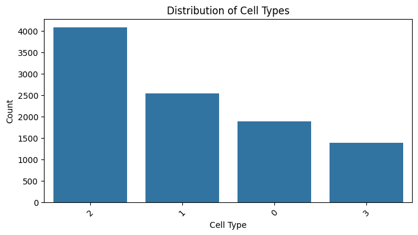

```
cellType
2    4079
1    2543
0    1888
3    1386
Name: count, dtype: int64
```

```python
# Visualising the distribution of cell types across rows and identifying class imbalance.
import seaborn as sns
import pandas as pd
import matplotlib.pyplot as plt

plt.figure(figsize=(6,4)) # Plotting the distribution of isCancerous
sns.countplot(data=data, x='isCancerous')
plt.title("Distribution of isCancerous Labels")
plt.xlabel("isCancerous (0 = Non-cancerous, 1 = Cancerous)")
plt.ylabel("Count")
plt.show()

print(data['isCancerous'].value_counts()) # Printing the raw values.

plt.figure(figsize=(8,4)) # Plotting the distribution of cellType.
sns.countplot(data=data, x='cellType', order=data['cellType'].value_counts().index)
plt.title("Distribution of Cell Types")
plt.xlabel("Cell Type")
plt.ylabel("Count")
plt.xticks(rotation=45)
plt.show()

print(data['cellType'].value_counts()) # Plotting the raw values.
```

```python
# Loading Images into the virtual enviroment for use.
import os
from PIL import Image
import matplotlib.pyplot as plt

image_dir = 'patch_images/'
image_files = os.listdir(image_dir)

print("Total images found:", len(image_files))
print("Sample filenames:", image_files[:5])
```

```
Total images found: 20280
Sample filenames: ['1.png', '10.png', '100.png', '1000.png', '10000.png']
```

```
Image 1: 1.png, size: (27, 27), mode: RGB
```

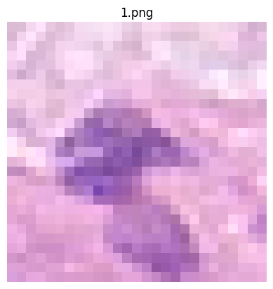

```
Image 2: 10.png, size: (27, 27), mode: RGB
```

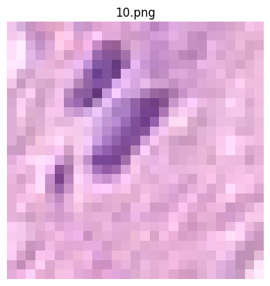

```
Image 3: 100.png, size: (27, 27), mode: RGB
```

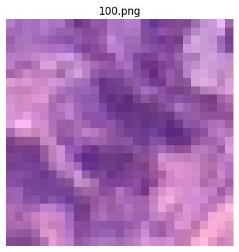

```
Image 4: 1000.png, size: (27, 27), mode: RGB
```

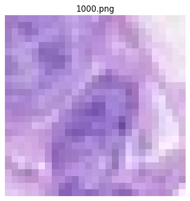

```
Image 5: 10000.png, size: (27, 27), mode: RGB
```

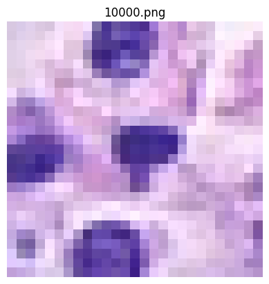

```python
# Visual inspection of sample images.
for i, file in enumerate(image_files[:5]):
    img_path = os.path.join(image_dir, file)
    img = Image.open(img_path)
    print(f"Image {i+1}: {file}, size: {img.size}, mode: {img.mode}")

    plt.imshow(img)
    plt.title(f"{file}")
    plt.axis('off')
    plt.show()
```

```python
# Checking for any missing images in dataset
import pandas as pd

df = pd.read_csv("data_labels_mainData.csv")
dfExtra = pd.read_csv("data_labels_extraData.csv")

csv_image_names = set(df['ImageName'])
csvExtra_image_names = set(dfExtra['ImageName'])
actual_image_names = set(image_files)

missing_in_folder = csv_image_names - actual_image_names
extra_in_folder = actual_image_names - csv_image_names

print("Missing images in folder:", len(missing_in_folder))
print("Extra images in folder:", len(extra_in_folder))
print("Total images:", len(actual_image_names))
print("Main data images:", len(csv_image_names))
print("Extra data images:", len(csvExtra_image_names))
```

```
Missing images in folder: 0
Extra images in folder: 10384
Total images: 20280
Main data images: 9896
Extra data images: 10384
```

### === Visual Inspection of Images ===

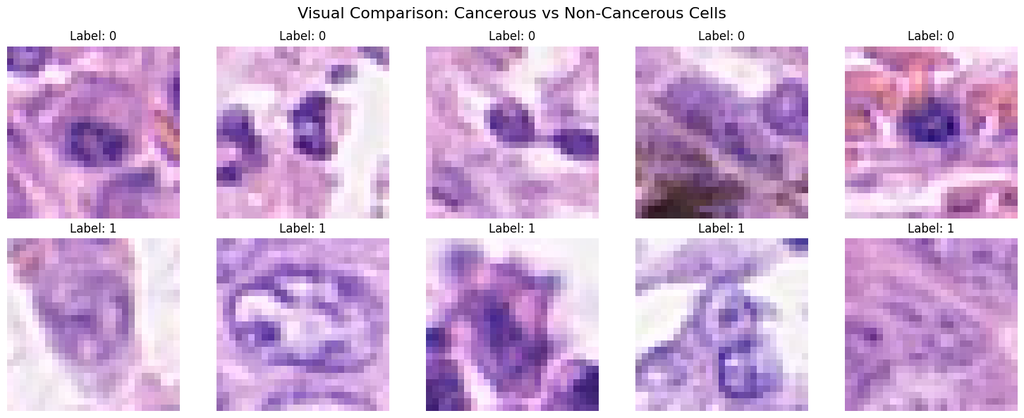

```python
# Plot a few cancerous and non-cancerous images side by side.
fig, axs = plt.subplots(2, 5, figsize=(15, 6))
classes = [0, 1]

for row, label in enumerate(classes):
    subset = df[df['isCancerous'] == label].sample(5, random_state=42)

    for col, filename in enumerate(subset['ImageName']):
        img_path = os.path.join(image_dir, filename)
        img = Image.open(img_path)
        axs[row, col].imshow(img)
        axs[row, col].axis('off')
        axs[row, col].set_title(f"Label: {label}")

plt.suptitle("Visual Comparison: Cancerous vs Non-Cancerous Cells", fontsize=16)
plt.tight_layout()
plt.show()
```

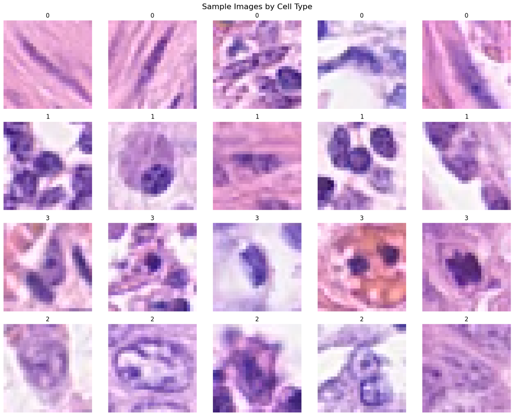

```python
# Visualising images by cell type to observe an obvious patterns.
cell_types = df['cellType'].unique()

fig, axs = plt.subplots(len(cell_types), 5, figsize=(15, 3 * len(cell_types)))

for i, ctype in enumerate(cell_types):
    samples = df[df['cellType'] == ctype].sample(5, random_state=42)

    for j, filename in enumerate(samples['ImageName']):
        img = Image.open(os.path.join(image_dir, filename))
        axs[i, j].imshow(img)
        axs[i, j].axis('off')
        axs[i, j].set_title(ctype)

plt.suptitle("Sample Images by Cell Type", fontsize=16)
plt.tight_layout()
plt.show()

# 0 = fibroblast
# 1 = inflammatory
# 2 = epithelial
# 3 = others
```

### === Image Statistics ===

```python
import numpy as np
from PIL import Image
import os
from tqdm import tqdm
import matplotlib.pyplot as plt

# Store per-image RGB means and class labels
image_means = []
class_labels = []

for _, row in tqdm(df.iterrows(), total=len(df)):
    filename = row['ImageName']
    label = row['cellType']  # or 'isCancerous' if binary classification

    img_path = os.path.join(image_dir, filename)
    img = Image.open(img_path).convert('RGB')
    arr = np.array(img)

    # Compute mean RGB for this image
    mean_rgb = np.mean(arr.reshape(-1, 3), axis=0)

    image_means.append(mean_rgb)
    class_labels.append(label)

# Convert to arrays for processing
image_means = np.array(image_means)
class_labels = np.array(class_labels)

# Sort by class label
sorted_indices = np.argsort(class_labels)
image_means_sorted = image_means[sorted_indices]
class_labels_sorted = class_labels[sorted_indices]

# Plot
plt.figure(figsize=(12, 6))
plt.plot(image_means_sorted[:, 0], label='Red Mean', color='red', alpha=0.6)
plt.plot(image_means_sorted[:, 1], label='Green Mean', color='green', alpha=0.6)
plt.plot(image_means_sorted[:, 2], label='Blue Mean', color='blue', alpha=0.6)

# add class label bands for visualization
unique_labels, label_positions = np.unique(class_labels_sorted, return_index=True)
for idx, label in zip(label_positions, unique_labels):
    plt.axvline(x=idx, color='gray', linestyle='--', alpha=0.4)
    plt.text(idx, 260, f'Class {label}', rotation=45, verticalalignment='bottom')

plt.title('Per-Image RGB Mean Values (Grouped by Class)')
plt.xlabel('Image Index (Sorted by Class)')
plt.ylabel('Mean Pixel Value (0–255)')
plt.legend()
plt.tight_layout()
plt.show()
```

[output not shown]

```python
def get_class_pixel_stats(label):
    subset = df[df['isCancerous'] == label]
    pixels = []
    for filename in subset['ImageName']:
        img = Image.open(os.path.join(image_dir, filename)).convert('RGB')
        pixels.append(np.array(img))
    flat = np.stack(pixels).reshape(-1, 3)
    return np.mean(flat, axis=0), np.std(flat, axis=0)

mean_0, std_0 = get_class_pixel_stats(0)
mean_1, std_1 = get_class_pixel_stats(1)

print("Non-cancerous Mean:", mean_0, "| Std:", std_0)
print("Cancerous Mean:", mean_1, "| Std:", std_1)
```

```
Non-cancerous Mean: [201.96138913 157.94195246 206.81942219] | Std: [43.72277866 50.90752328 32.67643504]
Cancerous Mean: [181.59094206 138.98914915 203.17913829] | Std: [40.76874649 45.89625997 29.59015706]
```

## Class Imbalance

By observing the distribution of the isCancerous and cellType columns, it is clear that some classes are more present in the dataset than others. For "isCancerous" this dataset contains many more class "0" samples than class "1". This immediately effected the performance of the intial models as it predicted only for the majority class even after regularisation.

# Data Splitting

### In the code blocks below is the splitting of the dataset. The findings are discussed in a mark down at the end of the section.

```python
# To avoid the spillage of patients across the data splits, we ensure that each patient's data is only included in a singular dataset.
unique_patients = data['patientID'].unique()

train_ids, temp_ids = train_test_split(unique_patients, test_size=0.4, random_state=42)
val_ids, test_ids = train_test_split(temp_ids, test_size=0.5, random_state=42)

train_data = df[df['patientID'].isin(train_ids)]
val_data = df[df['patientID'].isin(val_ids)]
test_data = df[df['patientID'].isin(test_ids)]
```

```python
# Here you can see that there are no overlapping paitents across data splits
print(train_data['patientID'].unique())
print(test_data['patientID'].unique())
print(val_data['patientID'].unique())
```

```
[ 2  3  8 10 11 12 15 16 17 19 21 22 23 24 25 26 27 28 29 30 31 33 36 38
 39 40 42 43 45 48 50 52 54 56 57 60]
[ 1  4  6  9 13 20 32 37 41 51 55 58]
[ 5  7 14 18 34 35 44 46 47 49 53 59]
```

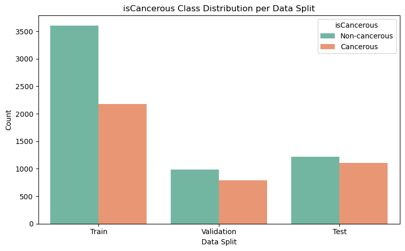

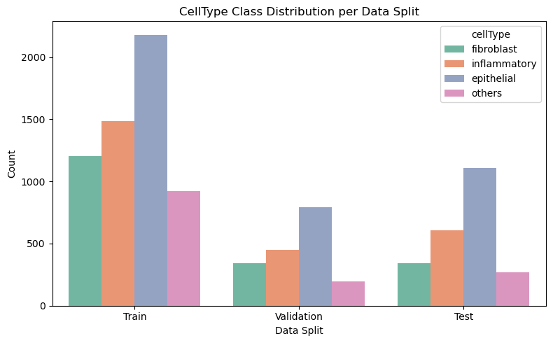

```python
# After splitting the data the distribution is visualised across the splits.
train_data_copy = train_data.copy()
train_data_copy['Split'] = 'Train'
val_data_copy = val_data.copy()
val_data_copy['Split'] = 'Validation'
test_data_copy = test_data.copy()
test_data_copy['Split'] = 'Test'
combined_data = pd.concat([train_data_copy, val_data_copy, test_data_copy])

plt.figure(figsize=(8, 5))
sns.countplot(data=combined_data, x='Split', hue='isCancerous', palette='Set2')

plt.title("isCancerous Class Distribution per Data Split")
plt.xlabel("Data Split")
plt.ylabel("Count")
plt.legend(title="isCancerous", labels=["Non-cancerous", "Cancerous"])
plt.tight_layout()
plt.show()

plt.figure(figsize=(8, 5))
sns.countplot(data=combined_data, x='Split', hue='cellType', palette='Set2')

plt.title("CellType Class Distribution per Data Split")
plt.xlabel("Data Split")
plt.ylabel("Count")
plt.legend(title="cellType", labels=["fibroblast", "inflammatory", "epithelial", "others"])
plt.tight_layout()
plt.show()

# 0 = fibroblast
# 1 = inflammatory
# 2 = epithelial
# 3 = others
```

## Data Splitting Observations

For our dataset we chose to split our data into **train, validation and test data** splits instead of using a cross validation approach. We chose this approach as our dataset is of a significant size and cross-validation would be very computationally expensive. We would also not be able to control if a patient's data would leak across the validation and train set (using cross-validation), so we opted for using clear splits where we could be sure each patients data stayed within one split.

We further prevented **data leakage** by designating every patients data to only a single dataset. We did this because in the EDA patients demonstrated having more data in some cellTypes than others. If a patients data was in both the training and testing set it would skew the models performance results and we would not be able to accurately assess the performance of the model.

### Data Preprocessing (Binary Classification)

```python
from collections import Counter
from torch.utils.data import Dataset
import torch
from torch.utils.data import DataLoader
import torchvision.transforms as transforms
import os
from torch.utils.data import ConcatDataset, DataLoader

# This class handles the image data and creates the image path. It also applies transformations if needed.
class ColonCancerDataset(Dataset):
    def __init__(self, data, img_dir, transform=None):
        self.data = data
        self.img_dir = img_dir
        self.transform = transform

    def __len__(self):
        return len(self.data)

    def __getitem__(self, idx):
        row = self.data.iloc[idx]
        img_path = os.path.join(self.img_dir, row['ImageName'])
        label = torch.tensor(row['isCancerous'], dtype=torch.float)
        img = Image.open(img_path).convert("RGB")
        if self.transform:
            img = self.transform(img)
        return img, label
```

```python
# This class expands upon the previous class by augmenting datasets that are passed in.
# This augmentation is done to handle class imbalance.
class AugmentedDataset(Dataset):
    def __init__(self, df, image_dir, transform, target_class, n_samples):
        self.df = df[df['isCancerous'] == target_class].reset_index(drop=True)
        self.image_dir = image_dir
        self.transform = transform
        self.n_samples = n_samples

    def __len__(self):
        return self.n_samples

    def __getitem__(self, idx):
        real_idx = idx % len(self.df)
        row = self.df.iloc[real_idx]
        image_path = os.path.join(self.image_dir, row['ImageName'])
        image = Image.open(image_path).convert("RGB")
        image = self.transform(image)
        label = torch.tensor(row['isCancerous'], dtype=torch.long)
        return image, label
```

```python
# These are the transformations applied to the datasets. They are called from within the classes.
train_transform = transforms.Compose([
    transforms.RandomHorizontalFlip(),
    transforms.RandomVerticalFlip(),
    transforms.RandomRotation(15),
    transforms.ToTensor(),
    transforms.Normalize(mean=[0.5]*3, std=[0.5]*3)
])

val_test_transform = transforms.Compose([
    transforms.ToTensor(),
    transforms.Normalize(mean=[0.5]*3, std=[0.5]*3)
])

augment_transform = transforms.Compose([
    transforms.RandomHorizontalFlip(),
    transforms.RandomRotation(20),
    transforms.ColorJitter(brightness=0.2, contrast=0.2, saturation=0.2),
    transforms.RandomAffine(degrees=15, translate=(0.1, 0.1)),
    transforms.ToTensor(),
    transforms.Normalize(mean=[0.5]*3, std=[0.5]*3)
])
```

```python
# Here we deal with the class imbalance by finding the difference between the majority and minority class.
class_counts = train_data['isCancerous'].value_counts()
majority_class = class_counts.idxmax()
minority_class = class_counts.idxmin()
n_to_augment = class_counts[majority_class] - class_counts[minority_class]

majority_df = train_data[train_data['isCancerous'] == majority_class] # Then we get a sample of the minority class.
minority_df = train_data[train_data['isCancerous'] == minority_class]
majority_df = majority_df.sample(n=len(minority_df), random_state=42)


# We create an instance of "AugmentedDataset" to increase the amount of the minority class.
augmented_minority_dataset = AugmentedDataset(train_data, image_dir="patch_images", transform=augment_transform, target_class=minority_class, n_samples=n_to_augment)
# Then we combine the original train data set and the augmented dataset.
train_base_dataset = ColonCancerDataset(pd.concat([majority_df, minority_df]), img_dir="patch_images", transform=train_transform)
balanced_train_dataset = ConcatDataset([train_base_dataset, augmented_minority_dataset])
# We create new instances of "ColonCancerDataset" for the validation and test dataset.
val_dataset = ColonCancerDataset(val_data, img_dir="patch_images", transform=val_test_transform)
test_dataset = ColonCancerDataset(test_data, img_dir="patch_images", transform=val_test_transform)

train_loader = DataLoader(balanced_train_dataset, batch_size=32, shuffle=True) # This is just intialising the loaders for the image data.
val_loader = DataLoader(val_dataset, batch_size=32, shuffle=False)
test_loader = DataLoader(test_dataset, batch_size=32, shuffle=False)

print("Train size:", len(balanced_train_dataset)) # Here we print out the sizes of each dataset after augmentation.
print("Val size:", len(val_dataset))
print("Test size:", len(test_dataset))
```

```
Train size: 5787
Val size: 1782
Test size: 2327
```

## Data Pre-Processing Justification

When creating our dataset classes we chose to use **normalisation** to help with the convergence speed during training and **augmentation** to deal with the class imbalance.

We normalised the images using transforms.Normalize, which scales the RGB pixels to be a range around 0. This is especially important for histopathelogy images as they can be taken in different clinics with different protocols, which could effect the lighting and quality of the images. By normalising the images we increase the generalisation ability of the model.

We performed data augmentation after identifying the class imbalance. This includes flipping the images horizontally and vertically, rotating the image and introducing colour jitter. The first two transformations are done to introduce spatial variety as colon cancer cells are not orientation specific. Colour jitter, which simulates different lighting conditions, will allow the model to learn the underlying patterns in the cells instead of relying on the RGB distribution of the image.

## Model Training

### == Binary Classification ==

### 1. Basic CNN Model

```python
import torch.nn as nn
import torch.nn.functional as func

class baseCNN(nn.Module): # This first Model is a basic CNN Model.
    def __init__(self, dropout_probability=0.5):
        super(baseCNN, self).__init__()
        self.con1 = nn.Conv2d(3, 16, kernel_size=3, padding=1)
        self.pool = nn.MaxPool2d(2,2)
        self.con2 = nn.Conv2d(16, 32, kernel_size=3, padding=1)

        self.fc1 = nn.Linear(32 * 6 * 6, 64)
        self.dropout = nn.Dropout(p=dropout_probability)
        self.fc2 = nn.Linear(64, 1)

    def forward(self, x):
        x = self.pool(func.relu(self.con1(x)))
        x = self.pool(func.relu(self.con2(x)))
        x = x.view(x.size(0), -1)
        x = func.relu(self.fc1(x))
        x = self.dropout(x)
        x = self.fc2(x)

        return x
```

```python
from torch.nn.modules.loss import BCEWithLogitsLoss
from torch.optim import lr_scheduler as lr

model = baseCNN() # This is initialising the hyperparameters of the model.

neg_count = (train_data['isCancerous'] == 0).sum()
pos_count = (train_data['isCancerous'] == 1).sum()
pos_weight = torch.tensor(neg_count / float(pos_count), dtype=torch.float)
criterion = nn.BCEWithLogitsLoss(pos_weight=pos_weight)

optimizer = torch.optim.Adam(model.parameters(), lr=1e-3, weight_decay=1e-5)
scheduler = lr.StepLR(optimizer, step_size=4, gamma=0.1)
```

```python
# This is the training loop that we use for all our binary models.
def train_model(model, train_data, val_data, criterion, optim, scheduler, epochs=10):
    for epoch in range(epochs):
        model.train()
        running_loss = 0.0
        correct = 0
        total = 0

        for inputs, labels in train_data:

            optim.zero_grad()
            outputs = model(inputs)
            loss = criterion(outputs, labels.unsqueeze(1))
            loss.backward()
            optim.step()

            running_loss += loss.item()
            preds = (outputs > 0.5).float()
            correct += (preds.view(-1) == labels).sum().item()
            total += labels.size(0)

        history['loss'].append(running_loss / len(train_loader))
        history['accuracy'].append(correct / total)

        print(f"Epoch {epoch+1}/{epochs} - Training Loss: {running_loss/len(train_loader):.4f}")

        scheduler.step()

        validate_model(model, val_data)
```

```python
# The training loop calls the validation loop.
def validate_model(model, val_data):
    model.eval()
    correct = 0
    total = 0
    val_loss = 0

    with torch.no_grad():
        for inputs, labels in val_data:
            outputs = model(inputs)
            loss = criterion(outputs, labels.unsqueeze(1))
            val_loss += loss.item()
            preds = (torch.sigmoid(outputs) > 0.5).int()
            correct += (preds.view(-1) == labels).sum().item()
            total += labels.size(0)

    history['val_loss'].append(val_loss / len(val_loader))
    history['val_accuracy'].append(correct / total)

    print(f"Validation Accuracy: {100 * correct / total:.2f}%")
```

```python
from sklearn.metrics import confusion_matrix, ConfusionMatrixDisplay, classification_report
import matplotlib.pyplot as plt

# After training we use this testing method to see the results of our model on unseen data.
def test_model(model, test_data):
    model.eval()
    correct = 0
    total = 0
    all_preds = []
    all_labels = []

    with torch.no_grad():
        for inputs, labels in test_data:
            outputs = model(inputs)
            preds = (outputs > 0.5).int()
            correct += (preds.view(-1) == labels).sum().item()
            total += labels.size(0)

            preds = (torch.sigmoid(outputs) > 0.5).int().view(-1)
            all_preds.extend(preds.cpu().numpy())
            all_labels.extend(labels.cpu().numpy())

    print(f"Test Accuracy: {100 * correct / total:.2f}%")

    cm = confusion_matrix(all_labels, all_preds)
    disp = ConfusionMatrixDisplay(confusion_matrix=cm, display_labels=["Non-cancerous", "Cancerous"])
    disp.plot(cmap=plt.cm.Blues)
    plt.title("Confusion Matrix")
    plt.show()

    print("Classification Report:")
    print(classification_report(all_labels, all_preds, target_names=["0", "1"]))
```

```python
def plot_learning_curve(train_loss, val_loss, train_metric, val_metric, metric_name='Accuracy'): # This is just a model for plotting the learning curve of each model.
    epochs = range(1, len(train_loss) + 1)

    fig, (ax1, ax2) = plt.subplots(1, 2, figsize=(14, 5))

    ax1.plot(epochs, train_loss, 'b-', label='Training Loss')
    ax1.plot(epochs, val_loss, 'r--', label='Validation Loss')
    ax1.set_title('Loss Curve')
    ax1.set_xlabel('Epoch')
    ax1.set_ylabel('Loss')
    ax1.legend()

    ax2.plot(epochs, train_metric, 'b-', label=f'Training {metric_name}')
    ax2.plot(epochs, val_metric, 'r--', label=f'Validation {metric_name}')
    ax2.set_title(f'{metric_name} Curve')
    ax2.set_xlabel('Epoch')
    ax2.set_ylabel(metric_name)
    ax2.legend()

    plt.tight_layout()
    plt.show()
```

```
Validation Accuracy: 86.64%
Validation Accuracy: 87.21%
Validation Accuracy: 81.76%
Validation Accuracy: 84.29%
Validation Accuracy: 86.36%
Validation Accuracy: 87.09%
Validation Accuracy: 85.07%
Validation Accuracy: 86.53%
Validation Accuracy: 86.42%
Validation Accuracy: 85.97%
Test Accuracy: 89.69%
```

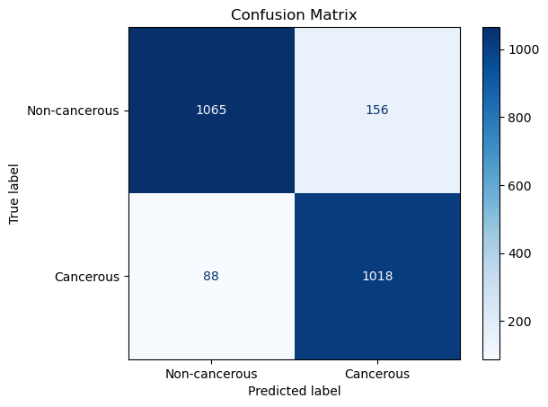

```
Classification Report:
              precision    recall  f1-score   support

           0       0.92      0.87      0.90      1221
           1       0.87      0.92      0.89      1106

    accuracy                           0.90      2327
   macro avg       0.90      0.90      0.90      2327
weighted avg       0.90      0.90      0.90      2327
```

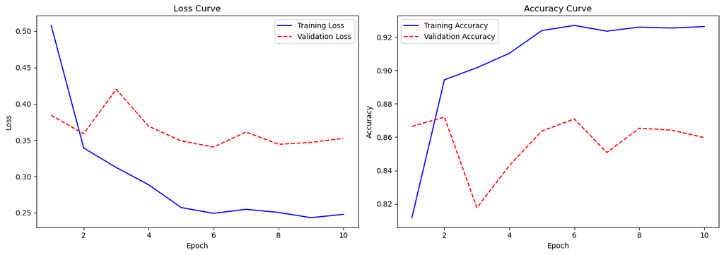

```python
# Here the model is train, validated and evaluated against the test data.
history = {'loss': [], 'val_loss': [], 'accuracy': [], 'val_accuracy': []}
train_model(model, train_loader, val_loader, criterion, optimizer, scheduler, epochs=10)
test_model(model, test_loader)
plot_learning_curve(history['loss'], history['val_loss'], history['accuracy'], history['val_accuracy'], metric_name='Accuracy')
```

### Basic Model Observations

This model is a basic convolutional neural network, we started with this model to have a bench mark for performance.

The architecture has two convolutional layers. The first layer has 16 filters and the second layer increases this to 32, both with a kernel size of 3 and padding of 1 to keep the original dimensions. Each convolutional layer was followed by a ReLu activaction and max-pooling layer with a kernel size of 2. The output of the convolutional layers was flattened and passed through a fully connected layer with a ReLu activaction, followed by a dropout layer(of 50%) to reduc overfitting. The final layer of the model produced a raw logit as a prediction.

We chose this simplistic CNN because we wanted to first explore CNN's ability to learn spatial patterns in image data. For our histopathelogy dataset, the patterns in texture and spatial structure were important in differentiating between cancerous and non-cancerous cells. So understanding the performance of a simplistic model allowed us to gauge the performance of other models.

Although we already handled the class imbalance in pre-processing, we added a pos_weight parameter and passed it into the BCEWithLogitsLoss function. By adjusting the loss function to penalise false negatives more heavily, we made the model more sensitive to class "1". Therefor further compensating for the class imbalance.

To optimise the model we used Adam optimiser with a learning rate of 0.001 and a weight decay of 1e-5 to introduce L2 regularisation. We also implemented a learning rate scheduler which reduced the learning rate by a factor of 0.1 every 4 epochs which helps the model to fine-tune weights in later epochs.

### 2. Residual CNN

```python
class ResidualBlock(nn.Module): # This is a residual block that is used in our residual model.
    def __init__(self, in_channels, out_channels):
        super().__init__()
        self.same_channels = in_channels == out_channels

        self.conv1 = nn.Conv2d(in_channels, out_channels, kernel_size=3, padding=1, bias=False)
        self.bn1 = nn.BatchNorm2d(out_channels)
        self.relu = nn.ReLU()
        self.conv2 = nn.Conv2d(out_channels, out_channels, kernel_size=3, padding=1, bias=False)
        self.bn2 = nn.BatchNorm2d(out_channels)

        if in_channels != out_channels:
            self.shortcut = nn.Sequential(nn.Sequential(nn.Conv2d(in_channels, out_channels, kernel_size=1, bias=False), nn.BatchNorm2d(out_channels)))
        else:
            self.shortcut = nn.Identity()

    def forward(self, x):
        identity = self.shortcut(x)
        out = self.conv1(x)
        out = self.bn1(out)
        out = self.relu(out)
        out = self.conv2(out)
        out = self.bn2(out)

        out += identity

        return self.relu(out)
```

```python
from torch import Tensor # This is the main model class for our residual model.
class ResidualModel(nn.Module):
    def __init__(self, in_channels: int =1):
        super().__init__()

        self.conv = nn.Conv2d(in_channels, 16, kernel_size=3, padding=1, bias=False)
        self.bn = nn.BatchNorm2d(16)
        self.relu = nn.ReLU()

        self.layer1 = nn.Sequential(ResidualBlock(16,16), ResidualBlock(16,16), nn.AvgPool2d(kernel_size=2))
        self.layer2 = nn.Sequential(ResidualBlock(16,32), ResidualBlock(32,32), nn.AvgPool2d(kernel_size=2))

        self.flatten = nn.Flatten()
        self.dropout = nn.Dropout(0.5)
        self.linear = nn.Linear(32 * 6 * 6, 1)

    def forward(self, x: Tensor):
        x = self.conv(x)
        x = self.bn(x)
        x = self.relu(x)

        x = self.layer1(x)
        x = self.layer2(x)

        x = self.flatten(x)
        x = self.dropout(x)
        x = self.linear(x)

        return x
```

```
Validation Accuracy: 82.72%
Validation Accuracy: 85.69%
Validation Accuracy: 86.08%
Validation Accuracy: 87.26%
Validation Accuracy: 87.82%
Validation Accuracy: 88.27%
Validation Accuracy: 86.64%
Validation Accuracy: 86.70%
Validation Accuracy: 88.44%
Validation Accuracy: 87.77%
Test Accuracy: 89.17%
```

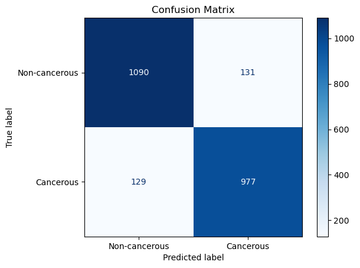

```
Classification Report:
              precision    recall  f1-score   support

           0       0.89      0.89      0.89      1221
           1       0.88      0.88      0.88      1106

    accuracy                           0.89      2327
   macro avg       0.89      0.89      0.89      2327
weighted avg       0.89      0.89      0.89      2327
```

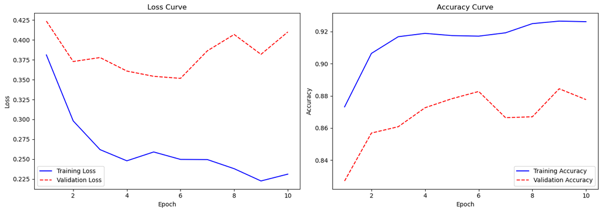

```python
model = ResidualModel(in_channels=3) # Here the model is trained, valiadted and tested. The hyperparameters are also initalised.

neg_count = (train_data['isCancerous'] == 0).sum()
pos_count = (train_data['isCancerous'] == 1).sum()
pos_weight = torch.tensor(neg_count / float(pos_count), dtype=torch.float)
criterion = nn.BCEWithLogitsLoss(pos_weight=pos_weight)

optimizer = torch.optim.Adam(model.parameters(), lr=1e-3, weight_decay=1e-5)
scheduler = lr.StepLR(optimizer, step_size=15, gamma=0.1)

history = {'loss': [], 'val_loss': [], 'accuracy': [], 'val_accuracy': []}
train_model(model, train_loader, val_loader, criterion, optimizer, scheduler, epochs=10)
test_model(model, test_loader)
plot_learning_curve(history['loss'], history['val_loss'], history['accuracy'], history['val_accuracy'], metric_name='Accuracy')
```

### Residual Model Observations

We chose a residual convolutional neural network to try find deeper hierarchal features in the image data. The architecture uses residual blocks, which allow the model to learn identity mapping and reduce the vanishing gradient problem. In the case of histopathological classification, where the cancerous variations of cells can be subtle, this function is particularly useful.

The same class imbalance methods were used across all three models, hence weighted binary cross-entropy loss was present in the training loop. The residual model was also optimised with Adam optimiser like the other models.

### 3. DenseNet

```python
from torchvision.models.densenet import DenseNet # This is the model class for our DenseNet model.

class DenseModel(nn.Module):
    def __init__(self, num_classes=1, growth_rate=32, block_config=(6,6,6), bin_size=4, dropout=0.0):
        super(DenseModel, self).__init__()

        self.features = DenseNet(num_init_features=32, num_classes=num_classes, growth_rate=growth_rate, block_config=block_config, bn_size=bin_size, drop_rate=dropout).features

        self.features.conv = nn.Conv2d(344, 32, kernel_size=3, stride=1, padding=1, bias=False)
        self.features.pool = nn.Identity()

        with torch.no_grad():
            self.eval()
            dummy = torch.randn(1, 3, 27, 27)
            out = self.features(dummy)
            out = func.relu(out)
            out = func.adaptive_avg_pool2d(out, (1, 1)).view(1, -1)
            feature_size = out.shape[1]
            self.train()

        self.classifier = nn.Linear(feature_size, num_classes)

    def forward(self, x):
        features = self.features(x)
        out = func.relu(features, inplace=True)
        out = func.adaptive_avg_pool2d(out, (1, 1)).view(x.size(0), -1)
        out = self.classifier(out)
        return out
```

```
Validation Accuracy: 78.79%
Validation Accuracy: 85.41%
Validation Accuracy: 85.75%
Validation Accuracy: 88.66%
Validation Accuracy: 81.31%
Validation Accuracy: 88.33%
Validation Accuracy: 89.28%
Validation Accuracy: 88.16%
Validation Accuracy: 84.68%
Validation Accuracy: 87.77%
Test Accuracy: 90.76%
```

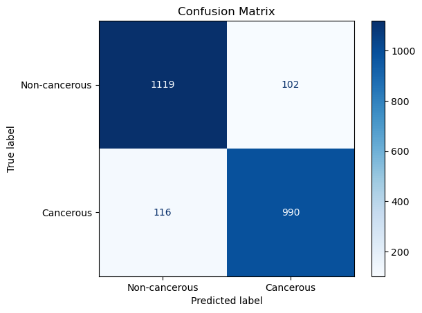

```
Classification Report:
              precision    recall  f1-score   support

           0       0.91      0.92      0.91      1221
           1       0.91      0.90      0.90      1106

    accuracy                           0.91      2327
   macro avg       0.91      0.91      0.91      2327
weighted avg       0.91      0.91      0.91      2327
```

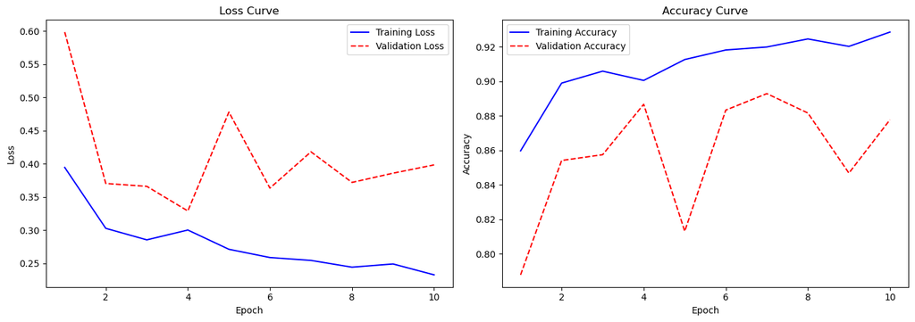

```python
model = DenseModel() # Here the model is trained, valiadted and tested. The hyperparameters are also initalised.

neg_count = (train_data['isCancerous'] == 0).sum()
pos_count = (train_data['isCancerous'] == 1).sum()
pos_weight = torch.tensor(neg_count / float(pos_count), dtype=torch.float)
criterion = nn.BCEWithLogitsLoss(pos_weight=pos_weight)

optimizer = torch.optim.Adam(model.parameters(), lr=1e-3, weight_decay=1e-5)
scheduler = lr.StepLR(optimizer, step_size=15, gamma=0.1)

history = {'loss': [], 'val_loss': [], 'accuracy': [], 'val_accuracy': []}
train_model(model, train_loader, val_loader, criterion, optimizer, scheduler, epochs=10)
test_model(model, test_loader)
plot_learning_curve(history['loss'], history['val_loss'], history['accuracy'], history['val_accuracy'], metric_name='Accuracy')
```

### DenseNet Model Observations

We chose DenseNet architecture as it has been extensively used in biomedical image analysis, specifically for histopathological image classification. Some examples include breast cancer detection and colorectal cancer grading. Its effectiveness comes from its dense connectivity pattern as each layer receives input from the preceding layers. This encourages feature reuse and results in compact models with less parameters. These can be especially useful in histopathology where datasets can be limited.

The architecture of this model consists of three dense blocks with six layers each, a growth rate of 32 and no dropout in the dense layers to retain as much information as possible. We customised the feature extractor by replacing the final convolution with a smaller 3x3 convolution that outputted 32 feature maps to account for the 27x27 input size. We removed the pooling and an adaptive average pooling was used in the forward pass to reduce dimensionality. To classify we used a linear layer that mapped the extracted features to a logit.

## == Multiclass Classification ==

### Data Preprocessing (Multiclass Classification)

```python
from collections import Counter
from torch.utils.data import Dataset
import torch
from torch.utils.data import DataLoader
import torchvision.transforms as transforms
import os
from torch.utils.data import ConcatDataset, DataLoader

# This class handles the image data and creates the image path. It also applies transformations if needed.
class CellTypeDataset(Dataset):
    def __init__(self, data, img_dir, transform=None):
        self.data = data
        self.img_dir = img_dir
        self.transform = transform

    def __len__(self):
        return len(self.data)

    def __getitem__(self, idx):
        row = self.data.iloc[idx]
        img_path = os.path.join(self.img_dir, row['ImageName'])
        label = torch.tensor(row['cellType'], dtype=torch.long) # long allows for multiclass classification
        img = Image.open(img_path).convert("RGB")
        if self.transform:
            img = self.transform(img)
        return img, label
```

```python
class UnlabeledImageDataset(Dataset):
    def __init__(self, df, img_dir, transform=None):
        self.df = df
        self.img_dir = img_dir
        self.transform = transform

    def __getitem__(self, idx):
        row = self.df.iloc[idx]
        image_path = os.path.join(self.img_dir, row['ImageName'])
        image = Image.open(image_path).convert('RGB')

        if self.transform:
            image = self.transform(image)

        return image

    def __len__(self):
        return len(self.df)
```

```python
# This class expands upon the previous class by augmenting datasets that are passed in.
# This augmentation is done to handle class imbalance.
class AugmentedMultiClassDataset(Dataset):
    def __init__(self, df, image_dir, transform, target_class, n_samples):
        self.df = df[df['cellType'] == target_class].reset_index(drop=True)
        self.image_dir = image_dir
        self.transform = transform
        self.n_samples = n_samples
        self.label = target_class
        self.label_dtype = torch.long

    def __len__(self):
        return self.n_samples

    def __getitem__(self, idx):
        real_idx = idx % len(self.df)
        row = self.df.iloc[real_idx]
        image_path = os.path.join(self.image_dir, row['ImageName'])
        image = Image.open(image_path).convert("RGB")
        image = self.transform(image)
        label = torch.tensor(self.label, dtype=self.label_dtype)
        return image, label
```

```python
# These are the transformations applied to the datasets. They are called from within the classes.
train_transform = transforms.Compose([
    transforms.RandomHorizontalFlip(),
    transforms.RandomVerticalFlip(),
    transforms.RandomRotation(15),
    transforms.ToTensor(),
    transforms.Normalize(mean=[0.5]*3, std=[0.5]*3)
])

val_test_transform = transforms.Compose([
    transforms.ToTensor(),
    transforms.Normalize(mean=[0.5]*3, std=[0.5]*3)
])

augment_transform = transforms.Compose([
    transforms.RandomHorizontalFlip(),
    transforms.RandomRotation(20),
    transforms.ColorJitter(brightness=0.2, contrast=0.2, saturation=0.2),
    transforms.RandomAffine(degrees=15, translate=(0.1, 0.1)),
    transforms.ToTensor(),
    transforms.Normalize(mean=[0.5]*3, std=[0.5]*3)
])
```

```python
# Dealing with class imbalances and finding the largest class
class_counts = train_data['cellType'].value_counts()
max_count = class_counts.max()

# Store datasets to combine later
base_datasets = []
augmented_datasets = []

for cell_type, count in class_counts.items():
    df_class = train_data[train_data['cellType'] == cell_type]

    # 1. If underrepresented -> augment
    if count < max_count:
        n_to_augment = max_count - count

        # Add original data
        base_datasets.append(CellTypeDataset(
            df_class,
            img_dir="patch_images",
            transform=train_transform
        ))

        # Add augmented synthetic samples
        augmented = AugmentedMultiClassDataset(
            df=train_data,
            image_dir="patch_images",
            transform=augment_transform,
            target_class=cell_type,
            n_samples=n_to_augment
        )
        augmented_datasets.append(augmented)

    # 2. If already at max count -> use directly
    else:
        base_datasets.append(CellTypeDataset(
            df_class.sample(n=max_count, random_state=42),
            img_dir="patch_images",
            transform=train_transform
        ))

# Combine all datasets
unlabeled_dataset = UnlabeledImageDataset(dfExtra, img_dir="patch_images", transform=val_test_transform)
unlabeled_loader = DataLoader(unlabeled_dataset, batch_size=64, shuffle=False)

balanced_train_dataset = ConcatDataset(base_datasets + augmented_datasets)

val_dataset = CellTypeDataset(val_data, img_dir="patch_images", transform=val_test_transform)
test_dataset = CellTypeDataset(test_data, img_dir="patch_images", transform=val_test_transform)

train_loader = DataLoader(balanced_train_dataset, batch_size=32, shuffle=True) # This is just intialising the loaders for the image data.
val_loader = DataLoader(val_dataset, batch_size=32, shuffle=False)
test_loader = DataLoader(test_dataset, batch_size=32, shuffle=False)


print("Train size:", len(balanced_train_dataset)) # Here we print out the sizes of each dataset after augmentation.
print("Val size:", len(val_dataset))
print("Test size:", len(test_dataset))
print("Extra size:", len(unlabeled_dataset))

from collections import Counter

# Count how many samples of each class exist in the final dataset
label_counter = Counter()

for i in range(len(balanced_train_dataset)):
    _, label = balanced_train_dataset[i]
    label_counter[int(label)] += 1

print("Balanced class distribution:", dict(label_counter))
```

```
Train size: 8720
Val size: 1782
Test size: 2327
Extra size: 10384
Balanced class distribution: {2: 2180, 1: 2180, 0: 2180, 3: 2180}
```

## Data Pre-Processing Justification

The preprocessing pipeline for multiclass classification of has been designed to ensure balanced class representation. The dataset initially suffers from class imbalance, where some cell types dominate in frequency while others are underrepresented. To address this, we used a combination of base datasets and synthetic augmentation via the `AugmentedMultiClassDataset` class. This guarantees that all four classes are equally represented in the final training dataset, which helps the model learn equally from all categories and prevents bias toward majority classes.

For underrepresented classes, additional synthetic samples are generated using aggressive transformations such as flipping, rotation, color jitter, and affine transformations. These augmentations simulate variations commonly seen in medical imaging, helping the model become more invariant to such changes. A separate transformation pipeline is used for validation and test datasets to ensure evaluation on unaltered images, maintaining consistency for performance assessment.

The use of `ConcatDataset` merges real and augmented data into a single unified training set, and all images are normalized to a standard RGB mean and std range which facilitates convergence in CNN training.

## 1. Basic CNN Model

```python
import torch.nn as nn
import torch.nn.functional as func

class baseCNN_MultiClass(nn.Module):
    def __init__(self, num_classes=4, dropout_probability=0.5):
        super(baseCNN_MultiClass, self).__init__()
        self.con1 = nn.Conv2d(3, 16, kernel_size=3, padding=1)
        self.bn1 = nn.BatchNorm2d(16)

        self.con2 = nn.Conv2d(16, 32, kernel_size=3, padding=1)
        self.bn2 = nn.BatchNorm2d(32)

        self.con3 = nn.Conv2d(32, 64, kernel_size=3, padding=1)
        self.bn3 = nn.BatchNorm2d(64)

        self.con4 = nn.Conv2d(64, 128, kernel_size=3, padding=1)
        self.bn4 = nn.BatchNorm2d(128)

        self.pool = nn.MaxPool2d(2,2)
        self.global_avg_pool = nn.AdaptiveAvgPool2d((1, 1))

        self.dropout = nn.Dropout(p=dropout_probability)
        self.fc = nn.Linear(128, num_classes)

    def forward(self, x):
        x = self.pool(func.relu(self.bn1(self.con1(x))))
        x = self.pool(func.relu(self.bn2(self.con2(x))))
        x = self.pool(func.relu(self.bn3(self.con3(x))))
        x = self.pool(func.relu(self.bn4(self.con4(x))))

        x = self.global_avg_pool(x)
        x = x.view(x.size(0), -1)

        x = self.dropout(x)
        x = self.fc(x)

        return x
```

```python
from torch.nn.modules.loss import BCEWithLogitsLoss
from torch.optim import lr_scheduler as lr
from sklearn.utils.class_weight import compute_class_weight

model = baseCNN_MultiClass(num_classes=4)

classes = np.unique(train_data['cellType'].values)
class_weights = compute_class_weight(class_weight='balanced', classes=classes, y=train_data['cellType'].values)
class_weights = torch.tensor(class_weights, dtype=torch.float)

criterion = FocalLoss(gamma=2.0, weight=class_weights)

optimizer = torch.optim.AdamW(model.parameters(), lr=1e-3, weight_decay=1e-5)
scheduler = lr.StepLR(optimizer, step_size=4, gamma=0.1)
```

```python
# This is the training loop that we use for all our multiclass models.
def train_model_multiclass(model, train_data, val_data, criterion, optim, scheduler, epochs=10, history=None):
    if history is None:
        history = {
            'loss': [],
            'val_loss': [],
            'accuracy': [],
            'val_accuracy': []
        }

    for epoch in range(epochs):
        model.train()
        running_loss = 0.0
        correct = 0
        total = 0

        for inputs, labels in train_loader:
            labels = labels.long()
            optim.zero_grad()
            outputs = model(inputs)
            loss = criterion(outputs, labels)
            loss.backward()
            optim.step()

            running_loss += loss.item()
            preds = torch.argmax(outputs, dim=1)
            correct += (preds == labels).sum().item()
            total += labels.size(0)

        epoch_loss = running_loss / len(train_loader)
        epoch_acc  = correct / total

        history['loss'].append(epoch_loss)
        history['accuracy'].append(epoch_acc)

        print(f"Epoch {epoch+1}/{epochs} - Training Loss: {running_loss/len(train_loader):.4f}")

        scheduler.step()

        validate_model_multiclass(model, val_loader, criterion, history)
```

```python
def validate_model_multiclass(model, val_loader, criterion, history):
    model.eval()
    correct = 0
    total = 0
    val_loss = 0.0

    with torch.no_grad():
        for inputs, labels in val_loader:
            labels = labels.long()
            outputs = model(inputs)  # shape: (batch_size, num_classes)
            loss = criterion(outputs, labels)  # labels: (batch_size,)
            val_loss += loss.item()

            # Get predicted class by taking the argmax
            preds = torch.argmax(outputs, dim=1)
            correct += (preds == labels).sum().item()
            total += labels.size(0)

    avg_loss = val_loss / len(val_loader)
    accuracy = correct / total

    if history is not None:
        history['val_loss'].append(avg_loss)
        history['val_accuracy'].append(accuracy)

    print(f"Validation Loss: {avg_loss:.4f} - Accuracy: {100 * accuracy:.2f}%")
```

```python
from sklearn.metrics import classification_report, confusion_matrix, ConfusionMatrixDisplay

def test_model_multiclass(model, test_loader, class_names=None):
    model.eval()
    correct = 0
    total = 0
    all_preds = []
    all_labels = []

    with torch.no_grad():
        for inputs, labels in test_loader:
            labels = labels.long()
            outputs = model(inputs)  # shape: (batch_size, num_classes)

            # Get predicted class (index of max logit)
            preds = torch.argmax(outputs, dim=1)

            correct += (preds == labels).sum().item()
            total += labels.size(0)

            all_preds.extend(preds.cpu().numpy())
            all_labels.extend(labels.cpu().numpy())

    # Accuracy
    accuracy = 100 * correct / total
    print(f"Test Accuracy: {accuracy:.2f}%")

    # Confusion Matrix
    cm = confusion_matrix(all_labels, all_preds)
    labels_to_display = class_names if class_names else sorted(set(all_labels))

    disp = ConfusionMatrixDisplay(confusion_matrix=cm, display_labels=labels_to_display)
    disp.plot(cmap=plt.cm.Blues, xticks_rotation=45)
    plt.title("Confusion Matrix (Multi-Class)")
    plt.tight_layout()
    plt.show()

    print("\n📊 Classification Report:")
    print(classification_report(all_labels, all_preds, target_names=class_names))
```

```python
def plot_learning_curve(train_loss, val_loss, train_metric, val_metric, metric_name='Accuracy'): # This is just a model for plotting the learning curve of each model.
    epochs = range(1, len(train_loss) + 1)

    fig, (ax1, ax2) = plt.subplots(1, 2, figsize=(14, 5))

    ax1.plot(epochs, train_loss, 'b-', label='Training Loss')
    ax1.plot(epochs, val_loss, 'r--', label='Validation Loss')
    ax1.set_title('Loss Curve')
    ax1.set_xlabel('Epoch')
    ax1.set_ylabel('Loss')
    ax1.legend()

    ax2.plot(epochs, train_metric, 'b-', label=f'Training {metric_name}')
    ax2.plot(epochs, val_metric, 'r--', label=f'Validation {metric_name}')
    ax2.set_title(f'{metric_name} Curve')
    ax2.set_xlabel('Epoch')
    ax2.set_ylabel(metric_name)
    ax2.legend()

    plt.tight_layout()
    plt.show()
```

```python
import torch
import torch.nn as nn
import torch.nn.functional as F

class FocalLoss(nn.Module):
    def __init__(self, gamma=2.0, weight=None, reduction='mean'):
        super(FocalLoss, self).__init__()
        self.gamma = gamma
        self.weight = weight
        self.reduction = reduction

    def forward(self, inputs, targets):
        log_probs = F.log_softmax(inputs, dim=1)         # log(p)
        probs = torch.exp(log_probs)                     # p

        targets_one_hot = F.one_hot(targets, num_classes=inputs.size(1)).float()
        focal_weight = (1 - probs) ** self.gamma         # (1 - p)^gamma

        loss = -targets_one_hot * focal_weight * log_probs

        if self.weight is not None:
            loss = loss * self.weight.unsqueeze(0)       # apply class weights

        loss = loss.sum(dim=1)  # sum over classes

        if self.reduction == 'mean':
            return loss.mean()
        elif self.reduction == 'sum':
            return loss.sum()
        return loss
```

```
Validation Loss: 0.4507 - Accuracy: 69.58%
Validation Loss: 0.4107 - Accuracy: 68.18%
Validation Loss: 0.3790 - Accuracy: 71.10%
Validation Loss: 0.3982 - Accuracy: 66.05%
Validation Loss: 0.3745 - Accuracy: 70.31%
Validation Loss: 0.3697 - Accuracy: 70.54%
Validation Loss: 0.3787 - Accuracy: 70.37%
Validation Loss: 0.3919 - Accuracy: 69.36%
Validation Loss: 0.3785 - Accuracy: 70.15%
Validation Loss: 0.3823 - Accuracy: 69.53%
Test Accuracy: 73.96%
```

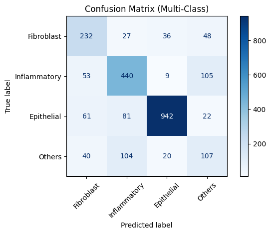

```
📊 Classification Report:
              precision    recall  f1-score   support

  Fibroblast       0.60      0.68      0.64       343
Inflammatory       0.67      0.72      0.70       607
  Epithelial       0.94      0.85      0.89      1106
      Others       0.38      0.39      0.39       271

    accuracy                           0.74      2327
   macro avg       0.65      0.66      0.65      2327
weighted avg       0.75      0.74      0.74      2327
```

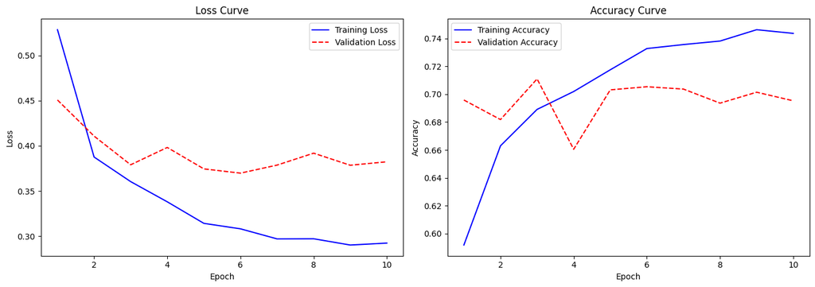

```python
# Initialize training history
history = {'loss': [], 'val_loss': [], 'accuracy': [], 'val_accuracy': []}

# Train the model
train_model_multiclass(
    model,
    train_loader,
    val_loader,
    criterion,
    optimizer,
    scheduler,
    epochs=10,
    history=history
)

# Test the model
class_names = ["Fibroblast", "Inflammatory", "Epithelial", "Others"]
test_model_multiclass(model, test_loader, class_names=class_names)

# Plot learning curves
plot_learning_curve(
    history['loss'],
    history['val_loss'],
    history['accuracy'],
    history['val_accuracy'],
    metric_name='Accuracy'
)
```

### BaseCNN Model Observations

The chosen architecture for this task is a lightweight CNN consisting of four convolutional layers, each followed by batch normalization, ReLU activation, and max pooling. A final global average pooling layer and dropout regularization precede the output classification layer. This structure is well-suited for 27x27 pixel histopathological image patches, capturing hierarchical features without introducing excessive model complexity. The use of batch normalization helps stabilize training, while adaptive pooling ensures consistent dimensionality regardless of input size. This design is intentionally simple to test the effectiveness of preprocessing and data balancing strategies before experimenting with deeper models.

Hyperparameters and training strategies have been carefully selected to complement the model architecture. Focal Loss is used instead of CrossEntropyLoss to address class imbalance by focusing training on harder-to-classify examples. The loss is weighted using computed `class_weights`, ensuring equal learning pressure across the four cell type categories. Additionally, a `StepLR` learning rate scheduler decays the learning rate every 4 epochs to promote convergence. The optimizer used is AdamW, a variant that integrates weight decay for regularization, minimizing overfitting risk. Together, these choices provide a well-tuned training regime for multiclass cell classification.

#### Classification Matrix

The confusion matrix reveals that the model performs best on the Epithelial class (class 2), achieving a precision of 0.94 and recall of 0.85. However, it struggles most with the "Others" class (class 3), which has the lowest F1-score (0.39), indicating misclassification with similar-looking cell types. "Fibroblast" and "Inflammatory" classes show moderate performance, with F1-scores of 0.64 and 0.70 respectively. These disparities likely stem from inter-class visual similarities and remaining class imbalance in the test set. The model has a macro average F1-score of 0.65 and a weighted average of 0.74, showing it performs reasonably well across the board, though further improvement is needed for the minority classes.

## 2. Custom Small Image CNN Model

```python
import torch
import torch.nn as nn
import torch.nn.functional as F
import numpy as np

class CustomSmallImageCNN(nn.Module):
    def __init__(self, num_classes=4, dropout_p=0.5):
        super(CustomSmallImageCNN, self).__init__()

        self.conv_block1 = nn.Sequential(
            nn.Conv2d(3, 32, kernel_size=3, padding=1),
            nn.BatchNorm2d(32),
            nn.ReLU(),
            nn.MaxPool2d(2, 2)  # 27x27 → 13x13
        )

        self.conv_block2 = nn.Sequential(
            nn.Conv2d(32, 64, kernel_size=3, padding=1),
            nn.BatchNorm2d(64),
            nn.ReLU(),
            nn.MaxPool2d(2, 2)  # 13x13 → 6x6
        )

        self.conv_block3 = nn.Sequential(
            nn.Conv2d(64, 128, kernel_size=3, padding=1),
            nn.BatchNorm2d(128),
            nn.ReLU(),
            nn.MaxPool2d(2, 2)  # 6x6 → 3x3
        )

        self.conv_block4 = nn.Sequential(
            nn.Conv2d(128, 256, kernel_size=3, padding=1),
            nn.BatchNorm2d(256),
            nn.ReLU(),
            nn.AdaptiveAvgPool2d((1, 1))  # 3x3 → 1x1
        )

        self.dropout = nn.Dropout(dropout_p)
        self.fc = nn.Linear(256, num_classes)

    def forward(self, x):
        x = self.conv_block1(x)
        x = self.conv_block2(x)
        x = self.conv_block3(x)
        x = self.conv_block4(x)

        x = x.view(x.size(0), -1)  # Flatten (B, 256, 1, 1) → (B, 256)
        x = self.dropout(x)
        x = self.fc(x)
        return x
```

```
Validation Loss: 0.3905 - Accuracy: 66.55%
Validation Loss: 0.4260 - Accuracy: 67.96%
Validation Loss: 0.3837 - Accuracy: 70.65%
Validation Loss: 0.4218 - Accuracy: 64.59%
Validation Loss: 0.3794 - Accuracy: 70.09%
Validation Loss: 0.3700 - Accuracy: 71.27%
Validation Loss: 0.3710 - Accuracy: 70.09%
Validation Loss: 0.3615 - Accuracy: 70.93%
Validation Loss: 0.3668 - Accuracy: 71.21%
Validation Loss: 0.3665 - Accuracy: 71.38%
Test Accuracy: 76.28%
```

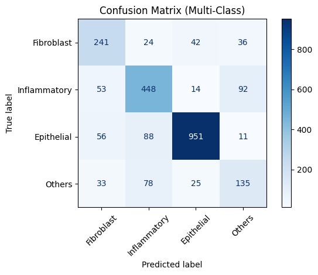

```
📊 Classification Report:
              precision    recall  f1-score   support

  Fibroblast       0.63      0.70      0.66       343
Inflammatory       0.70      0.74      0.72       607
  Epithelial       0.92      0.86      0.89      1106
      Others       0.49      0.50      0.50       271

    accuracy                           0.76      2327
   macro avg       0.69      0.70      0.69      2327
weighted avg       0.77      0.76      0.77      2327
```

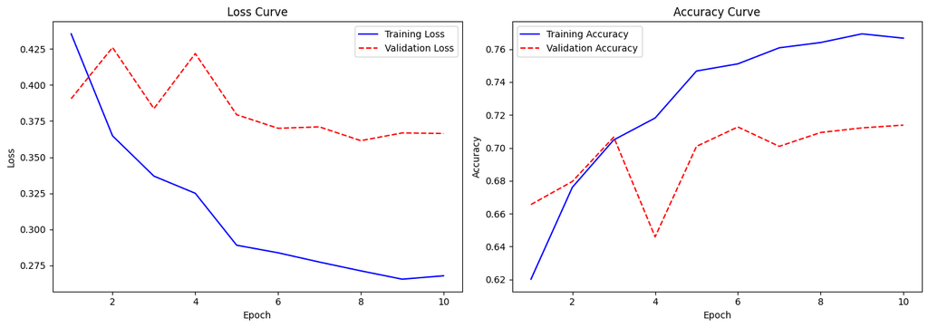

```python
# Instantiate Custom CNN model
model = CustomSmallImageCNN(num_classes=4)

criterion = FocalLoss(gamma=2.0, weight=class_weights)

# Use same optimizer and scheduler setup as before
optimizer = torch.optim.Adam(model.parameters(), lr=1e-3, weight_decay=1e-5)
scheduler = torch.optim.lr_scheduler.StepLR(optimizer, step_size=4, gamma=0.1)

# Initialize training history
history = {'loss': [], 'val_loss': [], 'accuracy': [], 'val_accuracy': []}

# Train the EfficientNet model
train_model_multiclass(
    model,
    train_loader,
    val_loader,
    criterion,
    optimizer,
    scheduler,
    epochs=10,
    history=history
)

# Evaluate on test set
class_names = ["Fibroblast", "Inflammatory", "Epithelial", "Others"]
test_model_multiclass(model, test_loader, class_names=class_names)

# Plot learning curves
plot_learning_curve(
    history['loss'],
    history['val_loss'],
    history['accuracy'],
    history['val_accuracy'],
    metric_name='Accuracy'
)
```

### Custom Small Image CNN Model Observations

This CNN architecture was specifically tailored for small histopathological images (27×27 pixels). It consists of four convolutional blocks using progressively increasing filter sizes from 32 to 256. Each block includes batch normalization, ReLU activation, and max pooling to reduce spatial dimensions. The final block uses adaptive average pooling to compress the feature map to 1×1 before classification, ensuring consistent output shape regardless of input resolution. This modular, sequential block design promotes clear gradient flow, while dropout before the fully connected layer combats overfitting. The model is compact yet expressive enough to capture cell type morphology in histology images.

## === Extra Images Classification ===

```python
base_model = CustomSmallImageCNN(num_classes=4)

criterion = FocalLoss(weight=class_weights)
optimizer = torch.optim.Adam(base_model.parameters(), lr=1e-3, weight_decay=1e-5)
scheduler = torch.optim.lr_scheduler.StepLR(optimizer, step_size=4, gamma=0.1)

history = {'loss': [], 'val_loss': [], 'accuracy': [], 'val_accuracy': []}

train_loader = DataLoader(balanced_train_dataset, batch_size=64, shuffle=True)
val_loader = DataLoader(val_dataset, batch_size=64, shuffle=False)

train_model_multiclass(
    base_model,
    train_loader,
    val_loader,
    criterion,
    optimizer,
    scheduler,
    epochs=10,
    history=history
)
```

```
Validation Loss: 0.7971 - Accuracy: 61.95%
Validation Loss: 0.5573 - Accuracy: 65.10%
Validation Loss: 0.4161 - Accuracy: 70.43%
Validation Loss: 0.4217 - Accuracy: 66.55%
Validation Loss: 0.3748 - Accuracy: 69.87%
Validation Loss: 0.3794 - Accuracy: 71.55%
Validation Loss: 0.3692 - Accuracy: 70.48%
Validation Loss: 0.3630 - Accuracy: 71.27%
Validation Loss: 0.3710 - Accuracy: 71.72%
Validation Loss: 0.3751 - Accuracy: 71.77%
```

```python
unlabeled_loader = DataLoader(unlabeled_dataset, batch_size=64, shuffle=False)

pseudo_inputs = []
pseudo_labels = []

base_model.eval()
with torch.no_grad():
    for inputs in unlabeled_loader:
        inputs = inputs
        outputs = base_model(inputs)
        probs = torch.softmax(outputs, dim=1)
        confidence, preds = probs.max(dim=1)

        mask = confidence > 0.88
        pseudo_inputs.append(inputs[mask])
        pseudo_labels.append(preds[mask])

pseudo_images = torch.cat(pseudo_inputs)
pseudo_targets = torch.cat(pseudo_labels)

print(f"Pseudo-labeled {len(pseudo_targets)} of {len(unlabeled_dataset)} images.")
```

```
Pseudo-labeled 1687 of 10384 images.
```

```python
pseudo_dataset = torch.utils.data.TensorDataset(pseudo_images, pseudo_targets)
combined_dataset = torch.utils.data.ConcatDataset([balanced_train_dataset, pseudo_dataset])
combined_loader = DataLoader(combined_dataset, batch_size=64, shuffle=True)
```

```
Validation Loss: 0.4462 - Accuracy: 68.57%
Validation Loss: 0.5365 - Accuracy: 57.86%
Validation Loss: 0.4051 - Accuracy: 63.92%
Validation Loss: 0.4241 - Accuracy: 63.80%
Validation Loss: 0.3772 - Accuracy: 69.92%
Validation Loss: 0.3742 - Accuracy: 70.54%
Validation Loss: 0.3663 - Accuracy: 71.04%
Validation Loss: 0.3696 - Accuracy: 70.15%
Validation Loss: 0.3679 - Accuracy: 70.54%
Validation Loss: 0.3708 - Accuracy: 70.82%
Test Accuracy: 75.76%
```

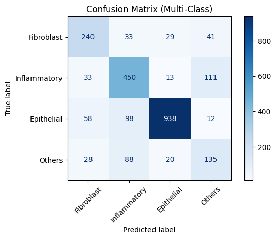

```
📊 Classification Report:
              precision    recall  f1-score   support

  Fibroblast       0.67      0.70      0.68       343
Inflammatory       0.67      0.74      0.71       607
  Epithelial       0.94      0.85      0.89      1106
      Others       0.45      0.50      0.47       271

    accuracy                           0.76      2327
   macro avg       0.68      0.70      0.69      2327
weighted avg       0.77      0.76      0.76      2327
```

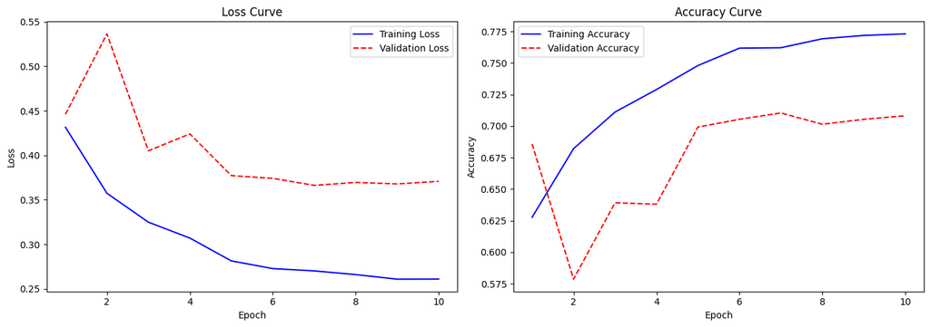

```python
new_model = CustomSmallImageCNN(num_classes=4)

criterion = FocalLoss(gamma=2.0, weight=class_weights)
optimizer = torch.optim.Adam(new_model.parameters(), lr=1e-3, weight_decay=1e-5)
scheduler = torch.optim.lr_scheduler.StepLR(optimizer, step_size=4, gamma=0.1)

combined_history = {'loss': [], 'val_loss': [], 'accuracy': [], 'val_accuracy': []}

train_model_multiclass(
    new_model,
    combined_loader,
    val_loader,
    criterion,
    optimizer,
    scheduler,
    epochs=10,
    history=combined_history
)

test_model_multiclass(new_model, test_loader, class_names=["Fibroblast", "Inflammatory", "Epithelial", "Others"])

plot_learning_curve(
    combined_history['loss'],
    combined_history['val_loss'],
    combined_history['accuracy'],
    combined_history['val_accuracy'],
    metric_name='Accuracy'
)
```

### Semi-Supervised CNN Model Observations

# Ultimate Judgement

## Binary Model

**Best Model Selected: DenseNet**

After evaluating all three models we determined that the DenseNet based model was the most effective for the binary classification task.

Despite the fact that all three models had similar accuracy, around 90%, there were some distinctions in the performance of their validation sets. The BaseCNN Model's validation loss from epoch to epoch did not decrease rather fluctuated with no positive or negative trend around the average loss of the training set. The validation sets accuracy for BaseCNN also fluctuated around the average of the training sets accuracy. So although the test accuracy of the model was 89%, this unusual behaviour of the validation set indicates that BaseCNN Model's performance on unseen may be impacted. The Residual Model's validation set loss was closer to a "good fit" as it decreased slightly and then stabilised at values higher than the training set. For accuracy, the validation set only increased by 4% from its first epoch to last. Though this is an improvement to the BaseCNN model the gap between the training and validation accuracy/loss was bigger than the DenseNet model. The DenseNet model's validation set loss and accuracy emulated that of the training sets. It was significantly closer to converging with the training set than the Residual Model, further justifying it as the better model.

The DenseNet Model's extensive connectivity and the consequential feature reuse means that the model learns representations even with fewer parameters. In the case of classifiying colon cancer, where the subtle variations in colour and texture define the classification, the model is able to retain both high level and low level features more efficiently than BaseCNN or the Residual Model. Another benefit of DenseNet's architecture is that each layer is directly connected, which makes training the model easier and reduces the issue of vanishing gradients.

Overall, the DenseNet model has multiple advantages in it's architecture and evidently its performance that make it more compatible with histpathology than other models. The model's ability to fit to the data was also demonstrated in the training and validation loss/accuracy across its training epochs. Adjustments to the training loop of the model, learning rate scheduling and weight decay, also helped the model to improve its classification ability. Therefor, the custom DenseNet Model architecture we created for this model both the best performing and optimised for generalisation out of the models we created for this binary classification task.

## Multi-Class Classification

**Best Model Selected: Semi-Supervised Custom CNN**

# Independent Evaluation

This section contains comparitive analysis of our best models for cell type and cancer cell tasks (defined in the ultimate judgement). This exercise is to explore how our models might perform in a real world setting, where retraining or changing the architecture of the model is not always possible.

### Cancer Cell Classification (Binary)

The DenseNet model that we chose as our best performing model has been extensively used in research pertaining to image classification in the histopathology field. It had an overall accuracy of 90%, f1-score of 0.90, recall of 0.90 and precision of 0.91 for the isCancerous class.

We shall be comparing it to a 2024 paper that used the features of VVG16 and ResNet101 models to create a Fused Feature Vector (FFV)[1]. This model reportedly >95% accuracy rate at classifying colorectal cancer images, which outperformed our DenseNet implementation. Their model utilised emsemble based feature fushion from two large pre-trained models, which likely benefitted from transfer learning on large scale data sets. The datasets used also had a significantly higher resolution to our 27x27 colon cancer dataset, which makes the increased representation nessecary to accomodate for the added information. When comparing to this work, we acknowledge that the differences in architecture, model depth, use of pretrained models and resolution and size of the training dataset limit a direct comparison. However our DenseNet model's accuracy of 90% is in a close range to the FFV and it achieved this with a much simpler architecture. Therefor our model may be more viable for resource limited enviroments like healthcare.

The next research paper proposed a Deep Convolutional Neural Network (DCNN) that achieved 94.7% accuracy in classifying colon adenocarcinomas [2]. The DCNN Model replaced with a sigmoid activation strategy that was designed to optimise transfer learning. Similarly to our DenseNet Model the DCNN Model preserved the original resolution of the images by avoiding excessive downsampling. This helped both models improve pattern revocognition even in small details. The paper also includes a full preprocessing pipeline, unlike our DenseNet Model with takes the raw inputs without any feature engineering. Although it is hard to compare the models fairly, the inclusion of a extensive preprocessing pipeline could be used to improve the DenseNet Model in future research. Ultimately, our DenseNet Model falls short compared to the accuracy of the DCNN Model proposed.

A key disadvantage to the external model's discussed is that they are very complex, and due to the deep nature of their architecture would be difficult to explain their classification process. Our DenseNet model takes on a much more simplistic architecture using minimally processed image inputs. This makes it more interpretable, which is nessecary if used to aid medical experts in the diagnostic process.

### Cell Type Classification (Multi-Class)

The semi-supervised CustomSmallImageCNN model, selected as our best performer for multiclass histopathological classification, can be further validated by comparing it against models from relevant literature. Our model achieved a test accuracy of 75.76%, using a dataset derived from the publicly available colon cancer histology images published by Sirinukunwattana et al. (2016) in *IEEE Transactions on Medical Imaging*. Their original study proposed a Locality-Sensitive Deep Learning framework which achieved high classification performance by exploiting spatial context and neighborhood information in cell detection and tissue classification. While our implementation focused solely on patch-wise classification using a small image CNN and additional unlabeled samples, it demonstrates how a simpler architecture can still yield reliable results with much lower computational overhead.

When compared to recent literature in the multiclass domain, our model falls short in raw accuracy compared to studies that utilize extensive transfer learning or ensemble approaches. For instance, more complex frameworks using pre-trained networks such as VGG16, ResNet101, and hybrid feature fusion have reported accuracies exceeding 90%. However, these models often rely on high-resolution data, aggressive preprocessing, and domain-specific tuning—making them less feasible in practical clinical environments with limited resources or real-time constraints. Our approach used 27×27 image patches, minimal preprocessing, and lightweight architecture, demonstrating a favorable trade-off between performance, interpretability, and scalability.

A key benefit of our model is its interpretable architecture and ability to incorporate unlabeled data through pseudo-labeling. This makes it suitable for real-world scenarios such as small clinics or research labs where access to large annotated datasets is limited. Furthermore, because our model does not rely on pretrained backbones or large image inputs, it is computationally affordable and easier to deploy on edge devices or integrated into clinical workflows. Compared to the architecture proposed by Sirinukunwattana et al., which integrates spatial relationships and local cell neighborhood features, our model is more patch-centric but still aligns with the dataset’s structural assumptions. Thus, while it does not outperform state-of-the-art methods in absolute terms, it presents a cost-effective, flexible, and adaptable solution for multiclass histopathology classification in resource-limited settings.

## Appendix

[1] V. Rajinikanth, R. Mohan and M. Narayanan, "Deep Learning and Features Fusion for Colorectal Cancer Detection from Histopathology Images," 2024 9th International Conference on Communication and Electronics Systems (ICCES), Coimbatore, India, 2024, pp. 1406-1411, doi: 10.1109/ICCES63552.2024.10859542.

[2] J. Smida, M. K. Azizi, A. S. C. Bose and A. Smida, "An Effective Approach for Detecting Colon Cancer Using Deep Convolutional Neural Network," 2024 IEEE International Conference on Advanced Systems and Emergent Technologies (IC_ASET), Hammamet, Tunisia, 2024, pp. 1-6, doi: 10.1109/IC_ASET61847.2024.10596175.

[3] K. Sirinukunwattana, S. E. A. Raza, Y. Tsang, D. R. J. Snead, I. A. Cree and N. M. Rajpoot, “Locality Sensitive Deep Learning for Detection and Classification of Nuclei in Routine Colon Cancer Histology Images,” IEEE Transactions on Medical Imaging, vol. 35, no. 5, pp. 1196–1206, May 2016. doi: 10.1109/TMI.2016.2525803

[4] Keylabs, “Best Practices Image preprocessing in image Classification | Keylabs,” Keylabs: Latest News and Updates, Aug. 14, 2024. https://keylabs.ai/blog/best-practices-for-image-preprocessing-in-image-classification/

[5] M. Politi, “Binary image classification in PyTorch - TDS Archive - Medium,” Medium, Jun. 01, 2022. [Online]. Available: https://medium.com/data-science/binary-image-classification-in-pytorch-5adf64f8c781

[6] C.-Y. Chang, “Building a Customized Residual CNN with PyTorch - Chen-Yu Chang - Medium,” Medium, May 31, 2024. [Online]. Available: https://medium.com/@chen-yu/building-a-customized-residual-cnn-with-pytorch-471810e894ed

[7] M. Kothari, “Comparison of different deep learning models for image classification,” Medium, Dec. 14, 2021. [Online]. Available: https://medium.com/@mahakkothari190.mk/comparison-of-different-deep-learning-models-for-image-classification-1c49f1159d7a

[8] rupert ai, “The U-Net (actually) explained in 10 minutes,” YouTube. May 05, 2023. [Online]. Available: https://www.youtube.com/watch?v=NhdzGfB1q74